# Weight Lifting Exercise Data Analysis

2026-04-15

## Introduction

This project analyzed data from accelerometers on the belt, forearm, arm, and dumbell of 6 participants. The goal of the analysis is to predict the manner in which the participants did the exercise. Manner of exercise execution is represented by variable “classe”. Prediction was performed by machine learning algorithms. Datasets and documentation are available from website here: http://groupware.les.inf.puc-rio.br/har

## Method

#### Dataset and library

*Training and testing data online were saved as .csv files before uploading to R*

```r
library(dplyr)
#load related libraries
library(AppliedPredictiveModeling)
library(ggplot2)
library(lattice)
library(caret)
library(Hmisc)
library(tibble)
library(bitops)
library(rattle)
library(rpart)
library(ElemStatLearn)
library(pgmm)
library(randomForest)
library(gbm3)
library(lubridate)
library(forecast)
library(e1071)
library(Matrix)
library(glmnet)
```

#### Data exploration and Pre-processing

*# Handle missing values*

```r
#Explore data
str(pmltrain)
dim(pmltrain)

#Remove missing >= 80%

missrate_train <- colMeans(is.na(pmltrain))
missrate_test <- colMeans(is.na(pmltest))

train_clean <- pmltrain[, missrate_train <= 0.8]
test_clean <- pmltest[, missrate_test <= 0.8]
```

*# More pre-processing*

```r
train_clean$user_name <- as.factor(train_clean$user_name)
test_clean$user_name <- as.factor(test_clean$user_name)

train_clean$cvtd_timestamp <- NULL
test_clean$cvtd_timestamp <- NULL
```

####Remove near-zero variance predictors

```r
nzv <- nearZeroVar(train_clean)

train_clean <- train_clean[, -nzv]
test_clean  <- test_clean[, -nzv]
```

*#Make sure columns match exactly*

```r
#align using intersection; remove outcome correctly
common_cols <- setdiff(intersect(names(train_clean), names(test_clean)), "classe")

train_clean <- train_clean[, c(common_cols, "classe")]
test_clean  <- test_clean[, common_cols]

setdiff(names(train_clean), names(test_clean))
```

```
## [1] "classe"
```

```r
#remove ID variables
names(train_clean)
```

```
##  [1] "X"                    "user_name"            "raw_timestamp_part_1"
##  [4] "raw_timestamp_part_2" "num_window"           "roll_belt"
##  [7] "pitch_belt"           "yaw_belt"             "total_accel_belt"
## [10] "roll_arm"             "pitch_arm"            "yaw_arm"
## [13] "total_accel_arm"      "gyros_arm_x"          "gyros_arm_y"
## [16] "gyros_arm_z"          "accel_arm_x"          "accel_arm_y"
## [19] "accel_arm_z"          "magnet_arm_x"         "magnet_arm_y"
## [22] "magnet_arm_z"         "roll_dumbbell"        "pitch_dumbbell"
## [25] "yaw_dumbbell"         "total_accel_dumbbell" "gyros_dumbbell_x"
## [28] "gyros_dumbbell_y"     "gyros_dumbbell_z"     "accel_dumbbell_x"
## [31] "accel_dumbbell_y"     "yaw_forearm"          "total_accel_forearm"
## [34] "gyros_forearm_x"      "classe"
```

```r
id_vars <- c(
  "X",
  "user_name",
  "raw_timestamp_part_1",
  "raw_timestamp_part_2",
  "cvtd_timestamp",
  "new_window",
  "num_window"
)

train_clean <- train_clean[, !(names(train_clean) %in% id_vars)]
test_clean  <- test_clean[, !(names(test_clean) %in% id_vars)]
```

*# Exploring distribution of continuous variables; Examine outliers*

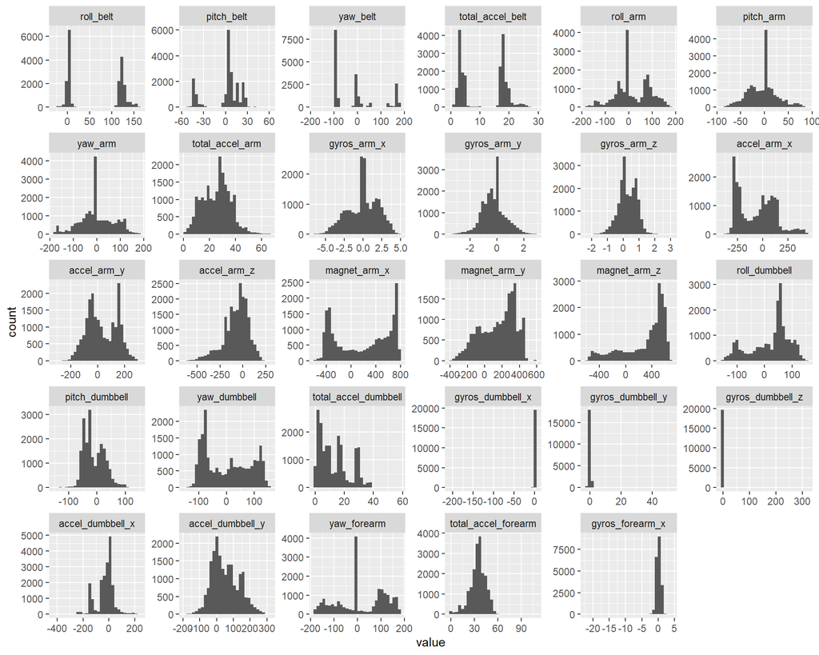

```r
summary(train_clean)

library(reshape2)
library(ggplot2)

num_vars <- train_clean[, sapply(train_clean, is.numeric)]
melted <- melt(num_vars)

ggplot(melted, aes(x = value)) +
  geom_histogram(bins = 30) +
  facet_wrap(~ variable, scales = "free")
```

##### With training data, predict ‘classe’ with all the other variables using “ranger” method

```r
library(ranger)
train_clean$classe <- as.factor(train_clean$classe)

set.seed(62433)
modFit <- train(classe ~ ., data=train_clean, method="ranger",
                 trControl = trainControl(method="cv", number=3, verboseIter=TRUE)
                )
modFit
```

```
## Random Forest
##
## 19622 samples
##    29 predictor
##     5 classes: 'A', 'B', 'C', 'D', 'E'
##
## No pre-processing
## Resampling: Cross-Validated (3 fold)
## Summary of sample sizes: 13082, 13080, 13082
## Resampling results across tuning parameters:
##
##   mtry  splitrule   Accuracy   Kappa
##    2    gini        0.9854755  0.9816266
##    2    extratrees  0.9830803  0.9785961
##   15    gini        0.9863418  0.9827255
##   15    extratrees  0.9890937  0.9862052
##   29    gini        0.9817552  0.9769263
##   29    extratrees  0.9901130  0.9874941
##
## Tuning parameter 'min.node.size' was held constant at a value of 1
## Accuracy was used to select the optimal model using the largest value.
## The final values used for the model were mtry = 29, splitrule = extratrees
##  and min.node.size = 1.
```

```r
pred <- predict(modFit, test_clean)
pred
```

```
##  [1] B A B A A E D B A A B C B A E E A B B B
## Levels: A B C D E
```

##### Model assessment (out of sample error) *3-fold cross-validation was used to tune the Random Forest model. Expected out-of-sample accuracy ranges from 0.989 to 0.990. Therefore, the out-of-sample error is expected to be from 0.010 to 0.011. If more stable estimate is desired, 5-fold or 10-fold cross-validation can be used.*